# Exploring Bikeshare data in R

The objective of this project is to explore data related to bike share systems for three major cities in the United States—Chicago, New York City, and Washington. For this, several R libraries will be used, making use of the different functions that help with the analysis and processing of data based on this language. For example, ggplot, lemon and visdat will be used for visualizations, while fasDummies, dplyr and plyr will be used for the manipulation of data.

## Table of Content:

## Introduction

As mentioned by the National Association of City Transportation Officials (NACTO), the US bike-share system is growing continuously, for example between 2016 and 2017 there was an increment of 25%. This increment in the use of the system is a consequence of the launch of several major new bike-share systems. Since 2010, more than 123 trips have been taken on bike share bikes in the U.S. Therefore, it is important to understand the data related with the bike share system to find new opportunities that could increase incomes of a similar business.

## Importing required libraries

In this section are imported different packages provided by R and different custom functions to be able to process and to analyze the previously mentioned data.

```r
Sys.setlocale("LC_TIME", "English")
library(plyr)
library(naniar)
library(visdat)
library(ggplot2)
library(ggExtra)
library(gridExtra)
library(repr)
library(reticulate)
library(lemon)
library(RColorBrewer)
library(fastDummies)
library(dplyr)
library(gridExtra)
library(cowplot)
library(cluster)
library(fpc)
source(file.path(getwd(),"Functions.R"))
```

'English_United States.1252'

## Reading data

In this section, the provided CSV data is loaded into R variables for their processing and analysis

```r
df.CHI <- read.csv(file=file.path(getwd(), "Data", "chicago.csv"), header=TRUE, sep=",")
df.NY <- read.csv(file=file.path(getwd(), "Data", "new_york_city.csv"), header=TRUE, sep=",")
df.WA <- read.csv(file=file.path(getwd(), "Data", "washington.csv"), header=TRUE, sep=",")
df.WA['Gender'] <- rep(NA, nrow(df.WA))
df.WA['Birth.Year'] <- rep(NA, nrow(df.WA))
```

The names of the cities related to the data are added to their respective dataframes to have more information.

```r
df.CHI["City"] <- "Chicago"
df.NY["City"] <- "New_York"
df.WA["City"] <- "Washington"
```

Example of the loaded data:

```r
head(df.CHI)
```

A data.frame: 6 × 10

|  | X <int> | Start.Time <fct> | End.Time <fct> | Trip.Duration <int> | Start.Station <fct> | End.Station <fct> | User.Type <fct> | Gender <fct> | Birth.Year <dbl> | City <chr> |
| --- | --- | --- | --- | --- | --- | --- | --- | --- | --- | --- |
| 1 | 1423854 | 2017-06-23 15:09:32 | 2017-06-23 15:14:53 | 321 | Wood St & Hubbard St | Damen Ave & Chicago Ave | Subscriber | Male | 1992 | Chicago |
| 2 | 955915 | 2017-05-25 18:19:03 | 2017-05-25 18:45:53 | 1610 | Theater on the Lake | Sheffield Ave & Waveland Ave | Subscriber | Female | 1992 | Chicago |
| 3 | 9031 | 2017-01-04 08:27:49 | 2017-01-04 08:34:45 | 416 | May St & Taylor St | Wood St & Taylor St | Subscriber | Male | 1981 | Chicago |
| 4 | 304487 | 2017-03-06 13:49:38 | 2017-03-06 13:55:28 | 350 | Christiana Ave & Lawrence Ave | St. Louis Ave & Balmoral Ave | Subscriber | Male | 1986 | Chicago |
| 5 | 45207 | 2017-01-17 14:53:07 | 2017-01-17 15:02:01 | 534 | Clark St & Randolph St | Desplaines St & Jackson Blvd | Subscriber | Male | 1975 | Chicago |
| 6 | 1473887 | 2017-06-26 09:01:20 | 2017-06-26 09:11:06 | 586 | Clinton St & Washington Blvd | Canal St & Taylor St | Subscriber | Male | 1990 | Chicago |

## Preprocessing the dataframe

### Content format

In this section, the names for the dataframe columns are changed, to be more descriptive and shorter. Besides, non-numerical categorical variables are converted to integers and dummy variables, for a more understandable processing and analysis of the data. Lastly, if some of the dataframes related to the loaded data miss some of the features contained in the rest of the data frames, those are added having as content nan values. This is possible using a custom function called PrePro1.

Creating dictionaries, list of lists, to retrieve the original names variables and content.

```r
dfGen <- rbind.fill(df.CHI, df.NY, df.WA)
Dict.CHI <- StationsFunc(df.CHI)
Dict.NY <- StationsFunc(df.NY)
Dict.WA <- StationsFunc(df.WA)
Days = c("Monday", "Tuesday", "Wednesday", "Thursday", "Friday", "Saturday", "Sunday")
Months = c("January", "February", "March", "April", "May", "June", "July", "August",
          "September", "October", "November", "December")
Travel_Type = unique(c("Short", "Regular", "Long"))
```

Combining the loading data and getting important date features for the analysis

```r
df.CHI <- PrePro1(df.CHI)
df.NY <- PrePro1(df.NY)
df.WA <- PrePro1(df.WA)
```

Example of the transformed data:

```r
head(df.CHI)
```

A data.frame: 6 × 13

|  | Index <int> | City <chr> | Month <int> | Day <int> | Hour <chr> | Duration_Sec <int> | Origin <list> | Destination <list> | Customer <int> | Subscriber <int> | Female <int> | Male <int> | Birth_Year <dbl> |
| --- | --- | --- | --- | --- | --- | --- | --- | --- | --- | --- | --- | --- | --- |
| 1 | 1 | Chicago | 6 | 5 | 15 | 321 | 1 | 229 | 0 | 1 | 0 | 1 | 1992 |
| 2 | 2 | Chicago | 5 | 4 | 18 | 1610 | 2 | 72 | 0 | 1 | 1 | 0 | 1992 |
| 3 | 3 | Chicago | 1 | 3 | 08 | 416 | 3 | 130 | 0 | 1 | 0 | 1 | 1981 |
| 4 | 4 | Chicago | 3 | 1 | 13 | 350 | 4 | 138 | 0 | 1 | 0 | 1 | 1986 |
| 5 | 5 | Chicago | 1 | 2 | 14 | 534 | 5 | 102 | 0 | 1 | 0 | 1 | 1975 |
| 6 | 6 | Chicago | 6 | 1 | 09 | 586 | 6 | 226 | 0 | 1 | 0 | 1 | 1990 |

### Removing NaN values

In this section are remove undefined values presented in the created dataframes, with the exception of the gender and birth year features. Two different types of undefined values are removed:

- Undefined values represented as strings, such as "NULL" or "NA"
- nan and null values presented, such as *NULL* and *NA*

Undefined values present in the gender and birth year related features are maintained since those are an indication that only users who are subscribed provided this information. Removing rows related with those features is the same as removing all data related to users that are not subscribed to the bike share system. Moreover, features represented as non-numerical values are converted to integers.

The removing of undefined values is possible using a custom function named PrePro2, such that:

```r
df.CHI <- PrePro2(df.CHI, names(df.CHI)[seq(3,length(names(df.CHI)))])
df.NY <- PrePro2(df.NY, names(df.NY)[seq(3,length(names(df.NY)))])
df.WA <- PrePro2(df.WA, names(df.WA)[seq(3,length(names(df.WA))-2)])
```

Exploring the processed dataframes to find undefined values and non-numerical features:

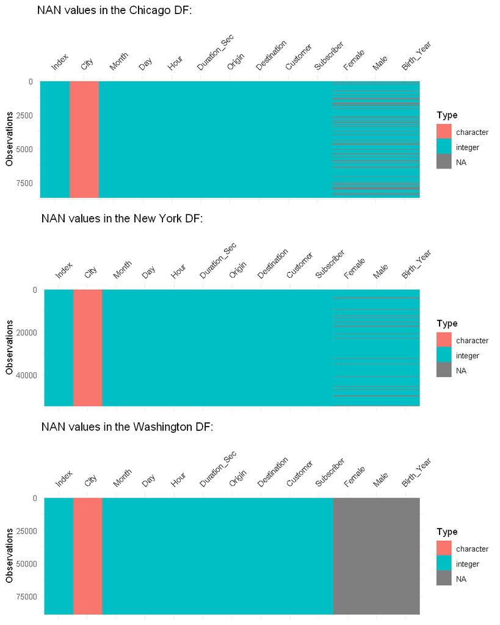

```r
options(repr.plot.width=8, repr.plot.height=10)
p1 <- vis_dat(df.CHI, sort_type = FALSE) + ggtitle("NAN values in the Chicago DF:")
p2 <- vis_dat(df.NY, sort_type = FALSE) + ggtitle("NAN values in the New York DF:")
p3 <- vis_dat(df.WA, sort_type = FALSE, warn_large_data=FALSE) + ggtitle("NAN values in the Washington DF:")

grid.arrange(p1, p2, p3, ncol = 1)
```

Summarizing the number of undefined values on each of the dataframe columns:

```r
NanValsCHI <- colSums(is.na(df.CHI))
NanValsNY <- colSums(is.na(df.NY))
NanValsWA <- colSums(is.na(df.WA))
NANVals <- data.frame(NanValsCHI, NanValsNY, NanValsWA)
NANVals
```

A data.frame: 13 × 3

|  | NanValsCHI <dbl> | NanValsNY <dbl> | NanValsWA <dbl> |
| --- | --- | --- | --- |
| Index | 0 | 0 | 0 |
| City | 0 | 0 | 0 |
| Month | 0 | 0 | 0 |
| Day | 0 | 0 | 0 |
| Hour | 0 | 0 | 0 |
| Duration_Sec | 0 | 0 | 0 |
| Origin | 0 | 0 | 0 |
| Destination | 0 | 0 | 0 |
| Customer | 0 | 0 | 0 |
| Subscriber | 0 | 0 | 0 |
| Female | 1747 | 5407 | 89050 |
| Male | 1747 | 5407 | 89050 |
| Birth_Year | 1746 | 5217 | 89050 |

### Creating features

Additional features are created for a better understanding of the sharing bike system. To be more specific, the travel_type feature is added, which classifies using 4 different levels the duration of the use of the bike by the users. In this case, the levels are defined by the TimeRate variables, presented in the next cell. Each of the variables defines the limit in the use of the bikes for the classification. This is possible using a custom function named PrePro3, as follow:

```r
TimeRate1 <- 5
TimeRate2 <- 15
TimeRate3 <- 30
TimeRate4 <- 45
df.CHI <- PrePro3(df.CHI, TimeRate1, TimeRate2, TimeRate3, TimeRate4)
df.NY <- PrePro3(df.NY, TimeRate1, TimeRate2, TimeRate3, TimeRate4)
df.WA <- PrePro3(df.WA, TimeRate1, TimeRate2, TimeRate3, TimeRate4)
```

Example of the created dataframe:

```r
head(df.CHI)
```

A data.frame: 6 × 14

|  | Index <int> | City <chr> | Month <int> | Day <int> | Hour <int> | Duration_Sec <int> | Travel_Type <int> | Origin <int> | Destination <int> | Customer <int> | Subscriber <int> | Female <int> | Male <int> | Birth_Year <int> |
| --- | --- | --- | --- | --- | --- | --- | --- | --- | --- | --- | --- | --- | --- | --- |
| 1 | 1 | Chicago | 6 | 5 | 15 | 321 | 1 | 1 | 229 | 0 | 1 | 0 | 1 | 1992 |
| 2 | 2 | Chicago | 5 | 4 | 18 | 1610 | 3 | 2 | 72 | 0 | 1 | 1 | 0 | 1992 |
| 3 | 3 | Chicago | 1 | 3 | 8 | 416 | 2 | 3 | 130 | 0 | 1 | 0 | 1 | 1981 |
| 4 | 4 | Chicago | 3 | 1 | 13 | 350 | 2 | 4 | 138 | 0 | 1 | 0 | 1 | 1986 |
| 5 | 5 | Chicago | 1 | 2 | 14 | 534 | 2 | 5 | 102 | 0 | 1 | 0 | 1 | 1975 |
| 6 | 6 | Chicago | 6 | 1 | 9 | 586 | 2 | 6 | 226 | 0 | 1 | 0 | 1 | 1990 |

## Exploring the data

### Data distributions

In this section are presented the distribution of the use of time for the three created and modified dataframes. It can be seen that the distributions represent gaussian processes but are skewed, given some bias towards the long tails. Therefore, it is required the reduction of outliers, to have a better representation of the gaussian processes.

[output not shown]

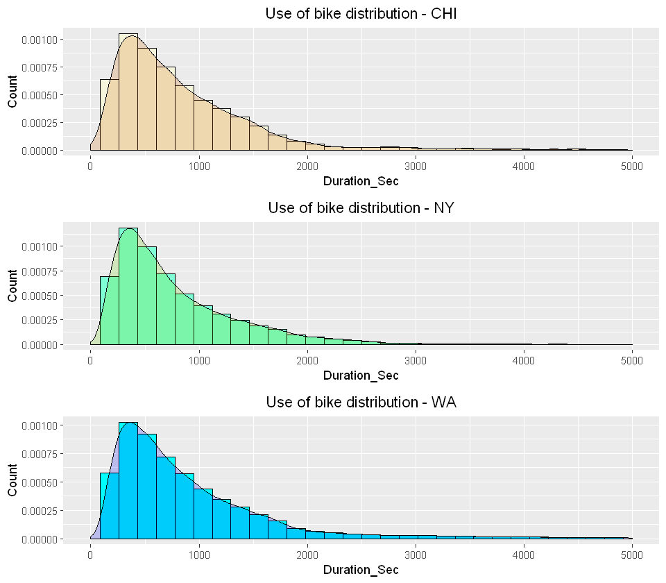

```r
options(repr.plot.width=8, repr.plot.height=7)
p1 <- ggplot(df.CHI[names(df.CHI)[seq(1,length(names(df.CHI))-3)]], aes(x=Duration_Sec)) +
      geom_histogram(aes(y=..density..), colour="black", fill="beige")+
      geom_density(alpha=.2, fill="darkorange3") +
      labs(x = 'Duration_Sec', y = "Count", title = 'Use of bike distribution - CHI') +
      theme(plot.title = element_text(hjust = 0.5))+
      scale_x_continuous(limits = c(0, 5000))

p2 <- ggplot(df.NY[names(df.NY)[seq(1,length(names(df.NY))-3)]], aes(x=Duration_Sec)) +
      geom_histogram(aes(y=..density..), colour="black", fill="aquamarine")+
      geom_density(alpha=.2, fill="chartreuse3") +
      labs(x = 'Duration_Sec', y = "Count", title = 'Use of bike distribution - NY')+
      theme(plot.title = element_text(hjust = 0.5))+
      scale_x_continuous(limits = c(0, 5000))

p3 <- ggplot(df.WA[names(df.WA)[seq(1,length(names(df.WA))-3)]], aes(x=Duration_Sec)) +
      geom_histogram(aes(y=..density..), colour="black", fill="cyan")+
      geom_density(alpha=.2, fill="blue2") +
      labs(x = 'Duration_Sec', y = "Count", title = 'Use of bike distribution - WA')+
      theme(plot.title = element_text(hjust = 0.5))+
      scale_x_continuous(limits = c(0, 5000))

plot_grid(p1, p2, p3, align = "v", nrow = 3)
```

### Features tendencies - Boxplots

#### Removing outliers

The outliers are removed based on a custom function called Rem_outliers, which calculate the 1st and 3rth quartiles for removing data located outside the IQR range:

```r
df.CHI <- Rem_Outiers(df.CHI, 'Duration_Sec')
df.NY <- Rem_Outiers(df.NY, 'Duration_Sec')
df.WA <- Rem_Outiers(df.WA, 'Duration_Sec')
```

#### Tendency of the bike share system located in Chicago

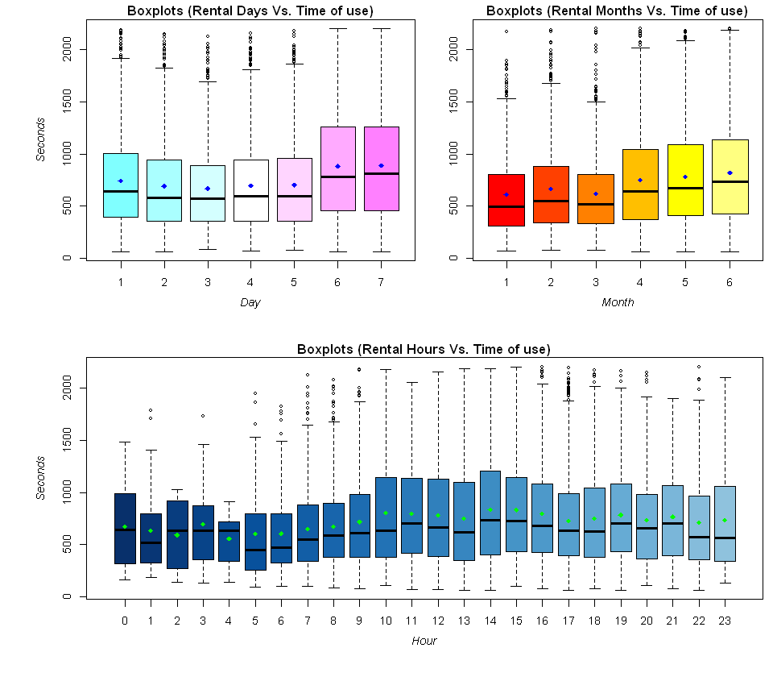

```r
PlotBoxplots(df.CHI)
```

**Tendency of the bike share system located in New York**

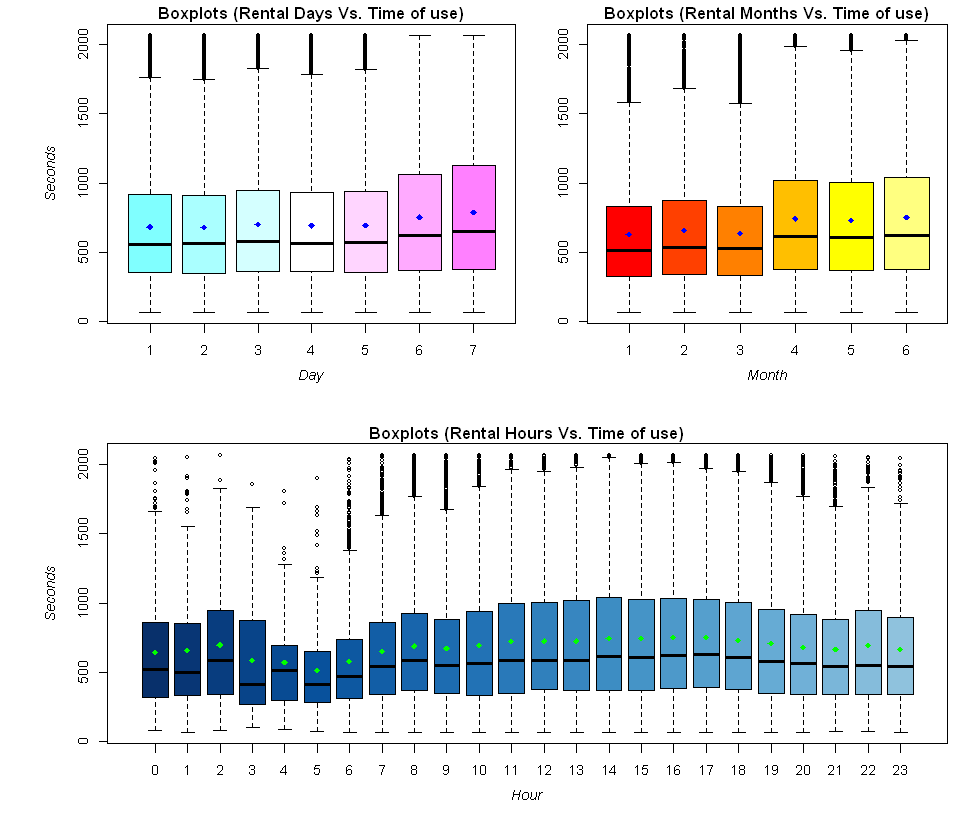

```r
PlotBoxplots(df.NY)
```

#### Tendency of the bike share system located in Washington

The bike-share system present in Washington presents a similar behaviour monthly and daily as the previously presented cases. However, when exploring the use of the system by the hour it can be seen that the system is used more between the 0 and 7 hours, in comparison with the other system located at different cities. It also presents a peak between 10 and 17 hours, as the previous cases.

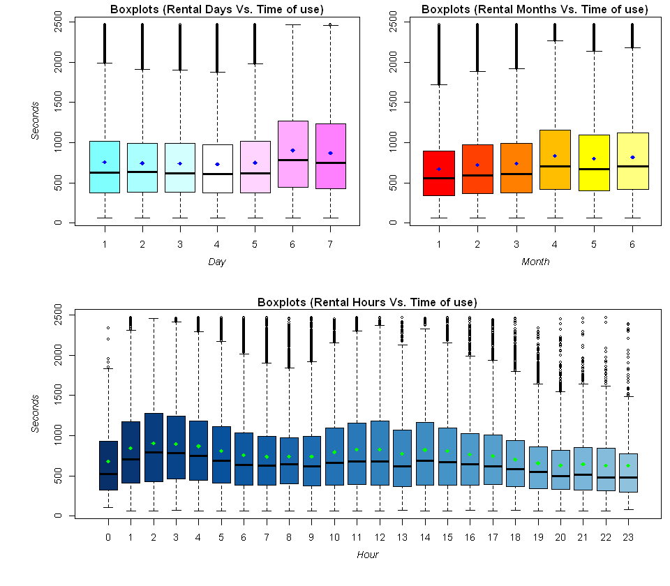

```r
PlotBoxplots(df.WA)
```

### Q1 - Routes for the uses of the bikes?

An additional characteristic to investigate is the relation between the origin and the destination of the users. This could help us to understand where the bikes are used more and why the differences in the duration of time for the uses of the bikes. Thus, the three dataframes related the cities of interest will be analyzed based on the features *Origin*, *Destination* and on the created feature *Travel_Type*. For this, it will be used the face_wrap ggplot characteristics. The stations that represent the origin and destination of the users are represented as integers, each of is used as the station names. Moreover, each of the numbers in which are divided the visualisation represents different periods of time for the use of bikes, such that:

- 1.- Less or equal to 5 minutes
- 2.- More than 5 minutes but less than 15 minutes
- 3.- More than 15 minutes but less than 30 minutes
- 4.- More than 30 minutes

The general statistics presented below show us the characteristics of the users of the bike share system in the cities of interest. For example, the number of stations where the bikes are rented and delivered, and the times of use for them. It also presents the number of users classified depending on the amount of time they use their bikes.

#### General Statistics - Chicago

- Statistics

```r
summary(df.CHI[,c('Duration_Sec','Origin', 'Destination', 'Travel_Type')])
```

```
  Duration_Sec        Origin       Destination     Travel_Type
 Min.   :  60.0   Min.   :  1.0   Min.   :  1.0   Min.   :1.000
 1st Qu.: 382.0   1st Qu.: 52.0   1st Qu.: 49.0   1st Qu.:2.000
 Median : 638.0   Median :116.0   Median :116.0   Median :2.000
 Mean   : 746.3   Mean   :142.8   Mean   :143.9   Mean   :2.133
 3rd Qu.:1035.0   3rd Qu.:219.0   3rd Qu.:223.0   3rd Qu.:3.000
 Max.   :2205.0   Max.   :470.0   Max.   :493.0   Max.   :4.000
```

- Types of Travels - Count

```r
A <- data.frame((table(df.CHI[,'Travel_Type'])))
names(A) <- c('Travel_Type', 'Num_of_Users')
A
```

A data.frame: 4 × 2

| Travel_Type <fct> | Num_of_Users <int> |
| --- | --- |
| 1 | 1584 |
| 2 | 4154 |
| 3 | 2266 |
| 4 | 205 |

#### General Statistics - New York

- Statistics

```r
summary(df.NY[,c('Duration_Sec','Origin', 'Destination', 'Travel_Type')])
```

```
  Duration_Sec        Origin       Destination     Travel_Type
 Min.   :  61.0   Min.   :  1.0   Min.   :  1.0   Min.   :1.000
 1st Qu.: 358.0   1st Qu.: 96.0   1st Qu.: 98.0   1st Qu.:2.000
 Median : 582.0   Median :201.0   Median :206.0   Median :2.000
 Mean   : 707.6   Mean   :228.8   Mean   :231.1   Mean   :2.074
 3rd Qu.: 964.0   3rd Qu.:345.0   3rd Qu.:349.0   3rd Qu.:3.000
 Max.   :2070.0   Max.   :635.0   Max.   :640.0   Max.   :4.000
```

- Types of Travels - Count

```r
A <- data.frame((table(df.NY[,'Travel_Type'])))
names(A) <- c('Travel_Type', 'Num_of_Users')
A
```

A data.frame: 4 × 2

| Travel_Type <fct> | Num_of_Users <int> |
| --- | --- |
| 1 | 11185 |
| 2 | 27057 |
| 3 | 12708 |
| 4 | 1178 |

#### General Statistics - Washington

- Statistics

```r
summary(df.WA[,c('Duration_Sec','Origin', 'Destination')])
```

```
  Duration_Sec        Origin       Destination
 Min.   :  60.0   Min.   :  1.0   Min.   :  1.0
 1st Qu.: 390.0   1st Qu.: 50.0   1st Qu.: 49.0
 Median : 650.0   Median :117.0   Median :117.0
 Mean   : 778.1   Mean   :132.2   Mean   :130.5
 3rd Qu.:1059.0   3rd Qu.:194.0   3rd Qu.:193.0
 Max.   :2467.0   Max.   :475.0   Max.   :481.0
```

- Types of Travels - Count

```r
A <- data.frame((table(df.WA[,'Travel_Type'])))
names(A) <- c('Travel_Type', 'Num_of_Users')
A
```

A data.frame: 4 × 2

| Travel_Type <fct> | Num_of_Users <int> |
| --- | --- |
| 1 | 14961 |
| 2 | 41054 |
| 3 | 22319 |
| 4 | 3427 |

#### Chicago routes

In Chicago, it can be seen that most of the users of the bike share system use their bikes more than 5 minutes but less than 15 minutes, and most of their routers are among stations represented as integers 1 to 150. The remaining users use their bikes less than 5 min and some of them more than 15 but less than 30 minutes. However, the remaining users are distributed mostly between station 1 to 200.

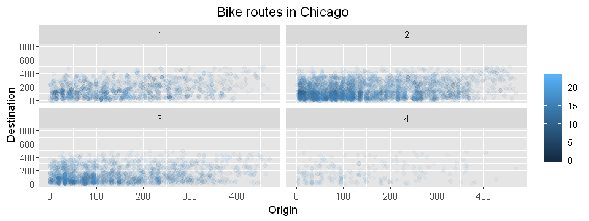

```r
options(repr.plot.width=8, repr.plot.height=3)
ggplot( aes(x = Origin, y = Destination, group = 2), data = df.CHI)+
  geom_point(alpha=1/20, aes(col=Hour)) + coord_cartesian(ylim = c(0,800)) +
  labs(title = 'Bike routes in Chicago') +   theme(legend.title = element_blank(), plot.title = element_text(hjust = 0.5),
  panel.background = element_rect(fill =  "grey90")) + facet_wrap(~Travel_Type)
```

#### New York routes

In New York, there is a bigger use of the bike share system. Most of them, as in the previous case, most of the users use their bikes more than 5 minutes but less than 15 minutes, and move between stations 1 to 400. The second bigger group of users use their bikes more than 15 minutes but less than 30 and is not that clear the most frequent routes for them. The last big group use their bikes less than 5 minutes, and there is not a clear route that is more used than the rest.

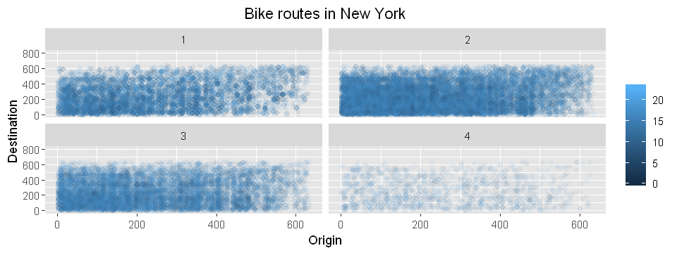

```r
options(repr.plot.width=8, repr.plot.height=3)
ggplot( aes(x = Origin, y = Destination, group = 2), data = df.NY)+
  geom_point(alpha=1/20, aes(col=Hour)) + coord_cartesian(ylim = c(0,800)) +
  labs(title = 'Bike routes in New York') +   theme(legend.title = element_blank(), plot.title = element_text(hjust = 0.5),
  panel.background = element_rect(fill =  "grey90")) + facet_wrap(~Travel_Type)
```

#### Washington routes

The bike-share system in Washington presents a more uniform use than in the previous case. There are three bigger groups of users, two of them travelling among similar stations. The first big group are users that use the bikes less than five minutes and move between stations 1 to 250. The rest of the bigger, users that use the bikes more than 5 minutes but less than 15 and more than 15 but less than 30. The users in both groups move among stations 1 to 290.

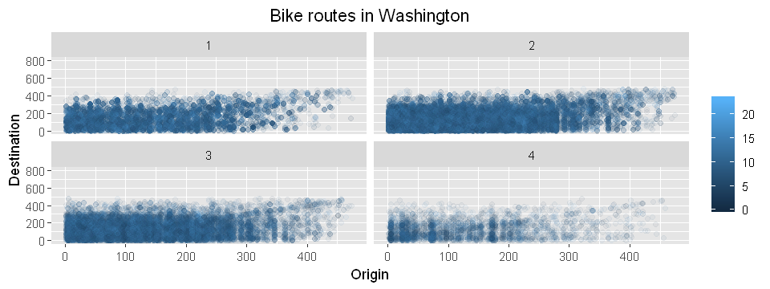

```r
options(repr.plot.width=8, repr.plot.height=3)
ggplot( aes(x = Origin, y = Destination, group = 2), data = df.WA)+
  geom_point(alpha=1/20, aes(col=Hour)) + coord_cartesian(ylim = c(0,800)) +
  labs(title = 'Bike routes in Washington') +   theme(legend.title = element_blank(), plot.title = element_text(hjust = 0.5),
  panel.background = element_rect(fill =  "grey90")) + facet_wrap(~Travel_Type)
```

### Q2 - Characteristics of the subscribers?

This section explores differences between the characteristics of the subscribers' users, such as their gender and the year of birth. This is possible using the distribution of users that highlight the differences between the mentioned characteristics, as presented in the next figure.

#### Chicago subscribers

It can be seen that the behaviour of the use of bikes is the same for both genders, but not the number of users. This is the same for the age of the users, both genders present a similar distribution, but with a difference. As a conclusion, there are not highlighted features that help us to understand better the use of the bike share system when comparing the gender of the subscribers of the system.

- Statistics Female Subscribers

```r
summary(df.CHI[df.CHI['Subscriber']==1 & df.CHI['Female']==1,c('Duration_Sec', 'Origin', 'Destination', 'Birth_Year')])
```

```
  Duration_Sec        Origin       Destination    Birth_Year
 Min.   :  60.0   Min.   :  1.0   Min.   :  1   Min.   :1944
 1st Qu.: 403.0   1st Qu.: 58.0   1st Qu.: 52   1st Qu.:1978
 Median : 660.0   Median :129.0   Median :123   Median :1986
 Mean   : 735.2   Mean   :153.7   Mean   :151   Mean   :1983
 3rd Qu.: 987.0   3rd Qu.:242.0   3rd Qu.:230   3rd Qu.:1990
 Max.   :2201.0   Max.   :468.0   Max.   :492   Max.   :2000
 NA's   :1        NA's   :1       NA's   :1     NA's   :1
```

- Statistics Male Subscribers

```r
summary(df.CHI[df.CHI['Subscriber']==1 & df.CHI['Male']==1,c('Duration_Sec', 'Origin', 'Destination', 'Birth_Year')])
```

```
  Duration_Sec        Origin       Destination      Birth_Year
 Min.   :  60.0   Min.   :  1.0   Min.   :  1.0   Min.   :1899
 1st Qu.: 335.5   1st Qu.: 55.0   1st Qu.: 52.0   1st Qu.:1974
 Median : 533.0   Median :116.0   Median :117.0   Median :1983
 Mean   : 631.1   Mean   :143.9   Mean   :147.2   Mean   :1980
 3rd Qu.: 836.0   3rd Qu.:219.0   3rd Qu.:227.0   3rd Qu.:1989
 Max.   :2180.0   Max.   :470.0   Max.   :493.0   Max.   :2002
 NA's   :1        NA's   :1       NA's   :1       NA's   :1
```

- Characteristics of the subscribers

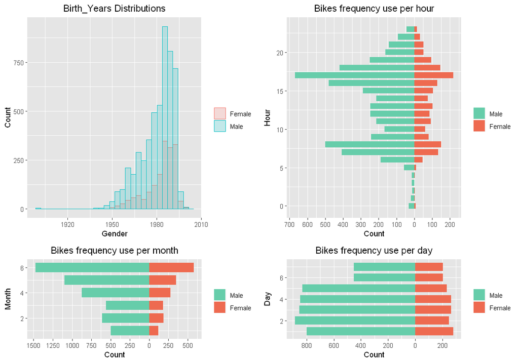

```r
options(repr.plot.width=10, repr.plot.height=7)
p1 <- PlotBYVsGender(df.CHI, 'Gender', 'Birth_Years Distributions')
p2 <- PlotUseFVsM(df.CHI, 'Hour', 'Gender', 'Male', 'Female', 'Bikes frequency use per hour', "right", 100)
p3 <- PlotUseFVsM(df.CHI, 'Month', 'Gender', 'Male', 'Female', 'Bikes frequency use per month', "right", 250)
p4 <- PlotUseFVsM(df.CHI, 'Day', 'Gender', 'Male', 'Female', 'Bikes frequency use per day', "right", 200)
plot_grid(p1, p2, p3, p4, align = "v", ncol=2, nrow = 2, rel_heights = c(2/3, 1/3))
```

#### New York subscribers

For the use of the New York share bike system, it presents the same behaviour for both genders, as before. There is not a clear difference, rather than the number of users by gender, in terms of the tendencies of use for the different selected metrics. The year of births, the behaviour of the time the bikes are used by month, day and hour are very similar among both genders, as presented next:

- Statistics Female Subscribers

```r
summary(df.NY[df.NY['Subscriber']==1 & df.NY['Female']==1,c('Duration_Sec', 'Origin', 'Destination', 'Birth_Year')])
```

```
  Duration_Sec        Origin       Destination      Birth_Year
 Min.   :  61.0   Min.   :  1.0   Min.   :  1.0   Min.   :1893
 1st Qu.: 385.2   1st Qu.: 98.0   1st Qu.: 99.0   1st Qu.:1970
 Median : 606.0   Median :211.0   Median :210.0   Median :1982
 Mean   : 722.8   Mean   :236.3   Mean   :234.9   Mean   :1979
 3rd Qu.: 968.0   3rd Qu.:356.0   3rd Qu.:352.0   3rd Qu.:1988
 Max.   :2069.0   Max.   :630.0   Max.   :638.0   Max.   :2001
 NA's   :640      NA's   :640     NA's   :640     NA's   :641
```

- Statistics Male Subscribers

```r
summary(df.NY[df.NY['Subscriber']==1 & df.NY['Male']==1,c('Duration_Sec', 'Origin', 'Destination', 'Birth_Year')])
```

```
  Duration_Sec        Origin       Destination      Birth_Year
 Min.   :  61.0   Min.   :  1.0   Min.   :  1.0   Min.   :1886
 1st Qu.: 333.0   1st Qu.: 96.0   1st Qu.: 98.0   1st Qu.:1970
 Median : 530.0   Median :200.0   Median :201.0   Median :1980
 Mean   : 647.2   Mean   :225.8   Mean   :228.5   Mean   :1978
 3rd Qu.: 856.0   3rd Qu.:339.0   3rd Qu.:345.0   3rd Qu.:1987
 Max.   :2070.0   Max.   :635.0   Max.   :640.0   Max.   :2001
 NA's   :640      NA's   :640     NA's   :640     NA's   :640
```

- Characteristics of the subscribers

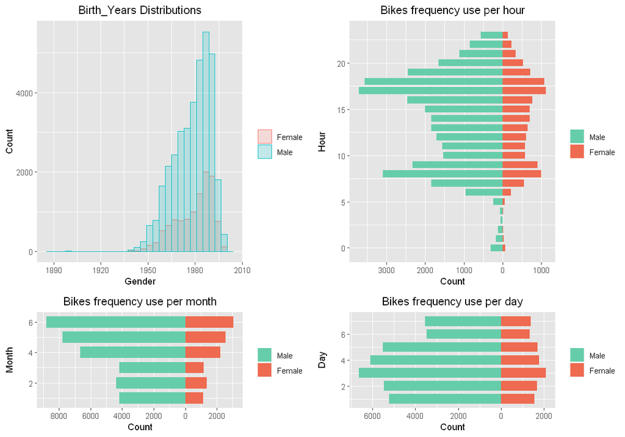

```r
options(repr.plot.width=10, repr.plot.height=7)
p1 <- PlotBYVsGender(df.NY, 'Gender', 'Birth_Years Distributions')
p2 <- PlotUseFVsM(df.NY, 'Hour', 'Gender', 'Male', 'Female', 'Bikes frequency use per hour', "right", 1000)
p3 <- PlotUseFVsM(df.NY, 'Month', 'Gender', 'Male', 'Female', 'Bikes frequency use per month', "right", 2000)
p4 <- PlotUseFVsM(df.NY, 'Day', 'Gender', 'Male', 'Female', 'Bikes frequency use per day', "right", 2000)
plot_grid(p1, p2, p3, p4, align = "v", ncol=2, nrow = 2, rel_heights = c(2/3, 1/3))
```

## Q3 - Differences between customers and subscribers?

The last feature to analyze is the difference in the behaviour of the use of bikes between the subscriber and non-subscriber users. For this, both users will be cluster to understand better their preferences. This will be possible using *k-means* to cluster the users, after finding the optimal number of centres for the clustering relying in the *Elbow method*. The Elbow method is implemented using the custom function ElbowFunct, which rely on the k-means R function to calculate the score for a specific number of centres selected. However, the implementation of the method is omitted for clarity within the notebook. Nonetheless, the optimal number of centres for the clustering, for all dataframes, is 10.

### Chicago users

After grouping the users it can be seen that both types of users, subscribers and costumers, have different behaviours. This can be observed better when comparing the time for the use of the bikes and the stations of origin and destination. However, both of them have specific behaviours, which can help the system to improve the use of bikes based o that, for example, having more bikes on specific stations.

- Subscribers Statistics

```r
summary(df.CHI[df.CHI['Subscriber']==1,c('Duration_Sec', 'Origin', 'Destination')])
```

```
  Duration_Sec        Origin       Destination
 Min.   :  60.0   Min.   :  1.0   Min.   :  1.0
 1st Qu.: 349.0   1st Qu.: 56.0   1st Qu.: 52.0
 Median : 560.0   Median :118.0   Median :118.0
 Mean   : 656.9   Mean   :146.4   Mean   :148.2
 3rd Qu.: 883.0   3rd Qu.:224.0   3rd Qu.:228.0
 Max.   :2201.0   Max.   :470.0   Max.   :493.0
```

- Customers Statistics

```r
summary(df.CHI[df.CHI['Customer']==1,c('Duration_Sec', 'Origin', 'Destination')])
```

```
  Duration_Sec        Origin       Destination
 Min.   :  63.0   Min.   :  1.0   Min.   :  2.0
 1st Qu.: 832.2   1st Qu.: 39.0   1st Qu.: 35.0
 Median :1195.0   Median : 94.0   Median : 94.0
 Mean   :1184.1   Mean   :125.2   Mean   :122.7
 3rd Qu.:1530.2   3rd Qu.:189.0   3rd Qu.:189.0
 Max.   :2205.0   Max.   :445.0   Max.   :487.0
```

- Creating subsets of the data containing only subscribers and non-subscribers, respectively:

```r
df.Temp1 <- df.CHI[df.CHI['Subscriber']==1,names(df.CHI)[seq(3,length(names(df.CHI))-5)]]
rownames(df.Temp1) <- 1:nrow(df.Temp1)
df.Temp2 <- df.CHI[df.CHI['Customer']==1,names(df.CHI)[seq(3,length(names(df.CHI))-5)]]
rownames(df.Temp2) <- 1:nrow(df.Temp2)
```

- Plotting the found clusters for both type of users:

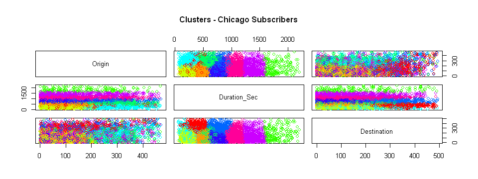

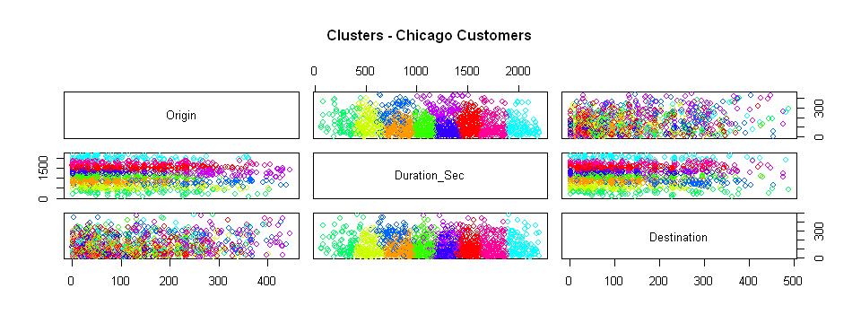

```r
n_groups = 10
PlotGroups(df.Temp1, n_groups, 100, 1, "Clusters - Chicago Subscribers")
PlotGroups(df.Temp2, n_groups, 100, 1, "Clusters - Chicago Customers")
```

### New York users

As in the Chicago analysis of users case, in New York, the subscribers and customers have different uses for the shared bike system, as can be observed in the next figure. The bigger difference is the number of users when compared with the previous case. Then, it is not possible to generalize the use of bikes considering only one type of user. Nevertheless, even when the groups are not the same, there exist some similarities.

- Subscribers Statistics

```r
summary(df.NY[df.NY['Subscriber']==1,c('Duration_Sec', 'Origin', 'Destination')])
```

```
  Duration_Sec        Origin       Destination
 Min.   :  61.0   Min.   :  1.0   Min.   :  1.0
 1st Qu.: 344.0   1st Qu.: 97.0   1st Qu.: 98.0
 Median : 548.0   Median :202.0   Median :205.0
 Mean   : 665.4   Mean   :228.8   Mean   :230.6
 3rd Qu.: 884.0   3rd Qu.:345.0   3rd Qu.:347.0
 Max.   :2070.0   Max.   :635.0   Max.   :640.0
```

- Customers Statistics

```r
summary(df.NY[df.NY['Customer']==1,c('Duration_Sec', 'Origin', 'Destination')])
```

```
  Duration_Sec        Origin       Destination
 Min.   :  62.0   Min.   :  1.0   Min.   :  1.0
 1st Qu.: 762.5   1st Qu.: 95.0   1st Qu.: 99.0
 Median :1172.0   Median :199.0   Median :212.0
 Mean   :1139.1   Mean   :229.3   Mean   :236.6
 3rd Qu.:1522.5   3rd Qu.:352.0   3rd Qu.:356.0
 Max.   :2070.0   Max.   :630.0   Max.   :635.0
```

- Creating subsets of the data containing only subscribers and non-subscribers, respectively:

```r
df.Temp1 <- df.NY[df.NY['Subscriber']==1,names(df.NY)[seq(3,length(names(df.NY))-5)]]
rownames(df.Temp1) <- 1:nrow(df.Temp1)
df.Temp2 <- df.NY[df.NY['Customer']==1,names(df.NY)[seq(3,length(names(df.NY))-5)]]
rownames(df.Temp2) <- 1:nrow(df.Temp2)
```

- Plotting the found clusters for both type of users:

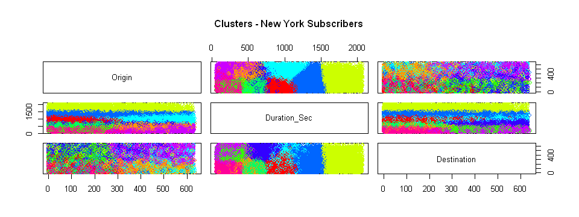

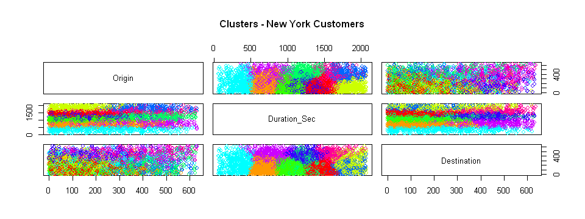

```r
n_groups = 10
PlotGroups(df.Temp1, n_groups, 100, 1, "Clusters - New York Subscribers")
PlotGroups(df.Temp2, n_groups, 100, 1, "Clusters - New York Customers")
```

### Washington users

As in the previous case, both types of users present different groups, but even when they are different there are some similarities. Probably with more information related to the data could help for a better clustering of the users, for example, users id, distance travelled, among others.

- Subscribers Statistics

```r
summary(df.WA[df.WA['Subscriber']==1,c('Duration_Sec', 'Origin', 'Destination')])
```

```
  Duration_Sec        Origin       Destination
 Min.   :  60.0   Min.   :  1.0   Min.   :  1.0
 1st Qu.: 352.0   1st Qu.: 55.0   1st Qu.: 55.0
 Median : 563.0   Median :121.0   Median :120.0
 Mean   : 666.4   Mean   :136.9   Mean   :135.1
 3rd Qu.: 885.0   3rd Qu.:201.0   3rd Qu.:195.0
 Max.   :2467.0   Max.   :474.0   Max.   :481.0
```

```r
summary(df.WA[df.WA['Subscriber']==1,c('Duration_Sec', 'Origin', 'Destination')])
```

[output not shown]

- Creating subsets of the data containing only subscribers and non-subscribers, respectively:

```r
df.Temp1 <- df.WA[df.WA['Subscriber']==1,names(df.WA)[seq(3,length(names(df.WA))-5)]]
rownames(df.Temp1) <- 1:nrow(df.Temp1)
df.Temp2 <- df.WA[df.WA['Customer']==1,names(df.WA)[seq(3,length(names(df.WA))-5)]]
rownames(df.Temp2) <- 1:nrow(df.Temp2)
```

- Plotting the found clusters for both type of users:

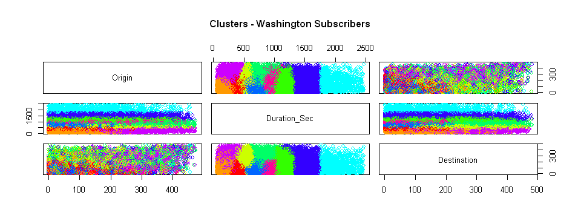

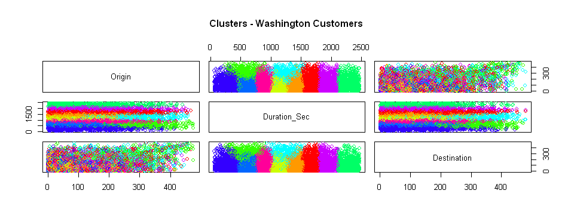

```r
n_groups = 10
PlotGroups(df.Temp1, n_groups, 100, 1, "Clusters - Washington Subscribers")
PlotGroups(df.Temp2, n_groups, 100, 1, "Clusters - Washington Customers")
```

## Conclusions

It can be concluded that the data provided for this analysis is enough to have an idea of how the bike-share systems behave. However, more information is required for a deeper analysis, one in which will be possible to forecast the use of bikes in the system. For this, it will be required prices, amount of time for the use of the bikes, the distance between stations, number of bikes available at each station, amount of time since the user became a subscriber, condition of the bikes at the stations, among others. Whit this information it will be possible to forecast the cost of operating each of the stations and which station to expand to increase the bike share system.